# Exam 02 Review

2019-11-21

```r
library(Sleuth3)
library(knitr)
library(broom)
library(tidyverse)
library(nnet)
library(cowplot)
```

### Data Description

- We would like to identify crab species based on the closing force and propodus height of claws
  - `ex0722` data set in the `Sleuth3` R package
- **Predictors:**
  - `Force`: Closing force of claw (newtons)
  - `Height`: Propodus height (mm)
- **Response:**
  - `Species`: Hemigrapsus nudus (Hn), Lophopanopeus bellus (Lb), Cancer productus (Cp)

### Part I: Lb species?

Suppose we want to use `Force` and `Height` to determine whether or not a crab is from the Lophopanopeus bellus (Lb) species.

**1. What type of model should we use? Briefly explain your choice.**

Logistic regression, because the response is categorical with two levels.

**2. Briefly explain how you would conduct exploratory data analysis.**

Below are some plots that can be used to conduct exploratory data analysis.

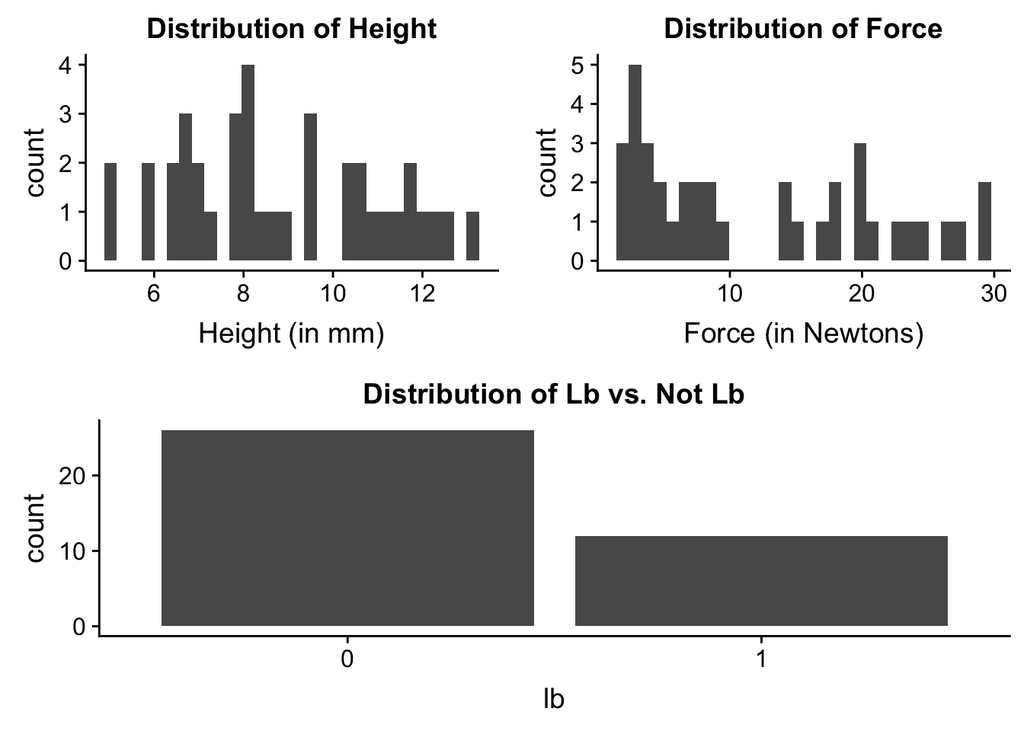

```r
p1 <- ggplot(data = claws, aes(x = Height)) +
  geom_histogram() +
  labs(title = "Distribution of Height",
       x = "Height (in mm)")

p2 <- ggplot(data = claws, aes(x = Force)) +
  geom_histogram() +
  labs(title = "Distribution of Force",
       x = "Force (in Newtons)")

p3 <- ggplot(data = claws, aes(x = lb)) +
  geom_bar() +
  labs(title = "Distribution of Lb vs. Not Lb")

top_row <- plot_grid(p1, p2, ncol = 2)

plot_grid(top_row, p3, ncol = 1)
```

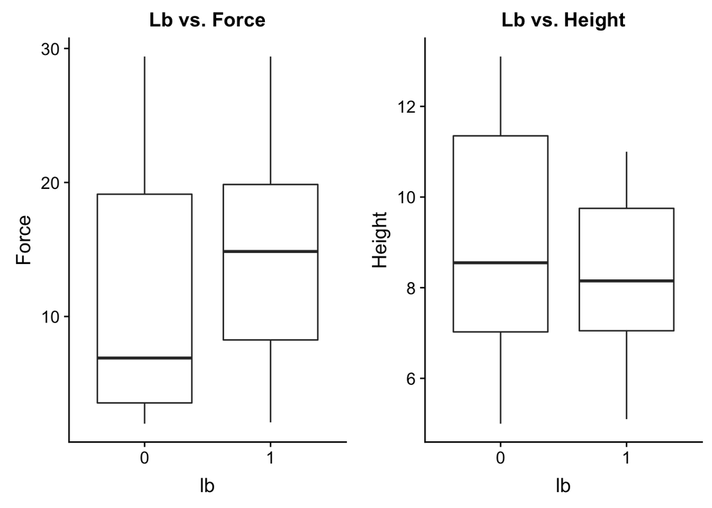

```r
p1 <- ggplot(data = claws, aes(x = lb, y = Force)) +
  geom_boxplot() +
  labs(title = "Lb vs. Force")

p2 <- ggplot(data = claws, aes(x = lb, y = Height)) +
  geom_boxplot() +
  labs(title = "Lb vs. Height")

plot_grid(p1, p2, ncol = 2)
```

We will use the mean-centered variables for `Force` and `Height`. The model output is below.

| term | estimate | std.error | statistic | p.value |
| --- | --- | --- | --- | --- |
| (Intercept) | -1.130 | 0.463 | -2.443 | 0.015 |
| forceCent | 0.211 | 0.092 | 2.279 | 0.023 |
| heightCent | -0.895 | 0.398 | -2.249 | 0.025 |

**3. Write the equation for the odds of a crab being from the Lb species.**

$$\color{blue}{\log\Big(\frac{\hat{p}}{1 - \hat{p}}\Big) = - 1.130 + 0.211 \times \text{ForceCent} - 0.895 \times \text{heightCent}}$$

**4. Interpret the intercept in the context of the problem.**

The odds that a crab with average claw force (12.134) and average claw height (8.813) is the Lb species is exp(-1.130) = 0.323.

**5. Interpret `forceCent` in the context of the problem.**

For each additional Newton in force, we expect the odds that a crab is the Lb species to multiply by exp(0.211) = 1.235 holding height constant.

The ROC curve is below.

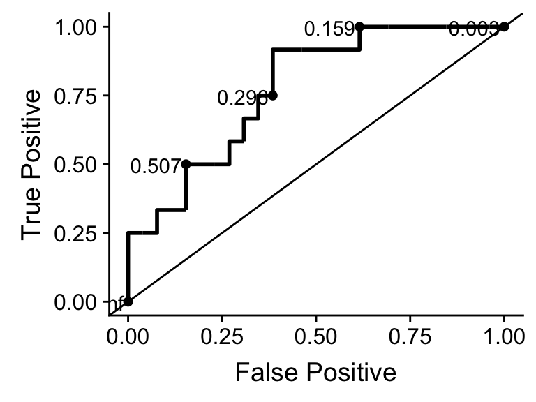

```
## [1] 0.775641
```

**6. What does *sensitivity* mean in the context of this data? What does *specificity* mean?**

Sensitivity: Correctly predicting a crab is the Lb species. Specificity: Correctly predicting a crab is not in the Lb species.

**7. Suppose we use a threshold of 0.507. What is the *sensitivity* at this threshold? What is the specificity?**

Sensitivity is about 0.5, and specificity is about 0.85.

### Part 2: Which species?

Suppose we want to use force and height to determine a crab’s species. The model output is below:

| y.level | term | estimate | std.error | statistic | p.value |
| --- | --- | --- | --- | --- | --- |
| Hn | (Intercept) | -1.193 | 1.106 | -1.079 | 0.281 |
| Hn | forceCent | -0.494 | 0.196 | -2.514 | 0.012 |
| Hn | heightCent | 0.179 | 0.474 | 0.378 | 0.705 |
| Lb | (Intercept) | 0.021 | 0.602 | 0.034 | 0.973 |
| Lb | forceCent | 0.095 | 0.101 | 0.941 | 0.347 |
| Lb | heightCent | -0.902 | 0.429 | -2.103 | 0.035 |

**1. Write the equation of the model.**

$$\color{blue}{\log\Big(\frac{\hat{p}_{Hn}}{\hat{p}_{Cp}}\Big) = -1.193 - 0.494 \times \text{ForceCent} + 0.179 \times \text{heightCent}}$$
$$\color{blue}{\log\Big(\frac{\hat{p}_{Lb}}{\hat{p}_{Cp}}\Big) = 0.021 + 0.095 \times \text{ForceCent} - 0.902 \times \text{heightCent}}$$

**2. Interpret the intercept for the odds a crab is Hn vs. Cp species.**

The odds that a crab with average claw force (12.134) and average claw height (8.813) is the Hn species vs. Cp species is exp(-1.193) = 0.303.

**3. Interpret the coefficient of `forceCent` for the odds a crab is Lb vs. Cp species.**

For each additional Newton in force, we expect the odds a crab is the Lb species vs. Cp species to multiply by exp(0.095) = 1.1 holding height constant.